# Untitled

Name

30/05/2020

## 0.1 Image Pre-Processing

```r
#----------------libraries used
library(tidyverse)          # data manipulation
library(imager)
library(repr)
library(rpart) #classification and regression trees
library(partykit) #treeplots
library(e1071) # SVM
library(randomForest)
library(C50)
library(factoextra)
library(caret) #tune hyper-parameters
library(pander)
library(klaR)
```

```r
# read images
directoryPos = paste(getwd(),"/","covid-positive", sep = "")
directoryNeg = paste(getwd(),"/","covid-negative", sep = "")
```

```r
filesCovidPos = list.files(path=directoryPos,pattern = "*.jpg", full.names=TRUE)
filesCovidNeg = list.files(path=directoryNeg,pattern = "*.jpeg", full.names=TRUE)
imagesCovidPos <- lapply(filesCovidPos, load.image )
imagesCovidNeg <- lapply(filesCovidNeg, load.image )
```

```r
test_image <- load.image(filesCovidPos[2])

# resizing,
resize_height <- 28
resize_width <- 28
resized_test_image <- resize(test_image, resize_width, resize_height)
pixels_to_crop <- 0
cropped_test_image <- crop.borders(resized_test_image, nPix = pixels_to_crop)
new_height <- dim(cropped_test_image)[1]
new_width <- dim(cropped_test_image)[2]
```

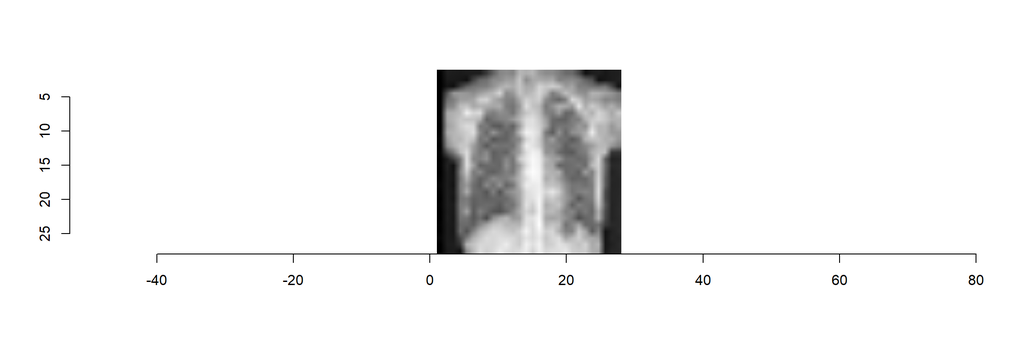

```r
# picture of the X-rays
plot(cropped_test_image)
```

Next, we inititalize our dataframe for every picture of covid-positive X-ray results for the training set:

```r
df_COVID19 <- data.frame(matrix(NA, nrow = length(filesCovidPos), ncol = new_height * new_width))
```

The most important (and lengthy) part of the process of data wrangling is going to be fitting every picture within the working directory into the dataframe we have just created.

```r
# very slow, 5 pictures per second (ie 5 minutes loading a 1341 picture dataset, but what gives, right?)
for (i in 1:length(filesCovidPos)) {
    im <- load.image(filesCovidPos[i])
    thmb <- resize(im, resize_height, resize_width) %>% crop.borders(nPix = pixels_to_crop) #%>% imsub(x %inr% c(1,3))
    df_COVID19 [i,] <- t(as.vector(thmb))
}
df_COVID19$y <- 1
```

To get finished with the class of covid-positive results, we add the corresponding label as a new column of our dataframe.

```r
str(df_COVID19)
```

```
## 'data.frame':    126 obs. of  785 variables:
##  $ X1  : num  0.00784 0 0.94902 0 0 ...
##  $ X2  : num  0.00784 0 0 0 0 ...
##  $ X3  : num  0.00392 0 0 0 0 ...
##  $ X4  : num  0.00784 0 0.00392 0 0 ...
##  $ X5  : num  0.00392 0 0 0 0 ...
##  $ X6  : num  0.0196 0.7098 0 0 0 ...
##  $ X7  : num  0.0431 0.9255 0.0196 0 0 ...
##  $ X8  : num  0.07843 0.85098 0.00392 0 0 ...
##  $ X9  : num  0.102 0.188 0 0 0 ...
##  $ X10 : num  0.07843 0.78824 0.00392 0 0 ...
##  $ X11 : num  0.416 0.643 0.553 0 0 ...
##  $ X12 : num  0.498 0.647 0.737 0 0 ...
##  $ X13 : num  0.557 0.792 0.788 0 0 ...
##  $ X14 : num  0.482 0.804 0.835 0 0 ...
```

[output cut: 86 more lines]

The following repeats the dataset building process for labels of the class Negative.

```r
test_image <- load.image(filesCovidNeg[2])
resized_test_image <- resize(test_image, resize_width, resize_height)
cropped_test_image <- crop.borders(resized_test_image, nPix = pixels_to_crop)
plot(cropped_test_image)

df_Negative <- data.frame(matrix(NA, nrow = length(filesCovidNeg), ncol = new_height * new_width))

start.time <- Sys.time()
for (i in 1:length(filesCovidNeg)) {
    im <- load.image(filesCovidNeg[i])
    thmb <- resize(im, resize_height, resize_width) %>% crop.borders(nPix = pixels_to_crop) #%>% imsub(x %inr% c(1,3))
    df_Negative[i,] <- t(as.vector(thmb))
}

end.time <- Sys.time()
interval <- end.time - start.time
print(interval)


df_Negative$y <- 0
```

[output not shown]

```r
str(df_Negative)
```

```
## 'data.frame':    260 obs. of  785 variables:
##  $ X1  : num  0 0.00784 0.00392 0 0.00392 ...
##  $ X2  : num  0.0902 0.1098 0.0392 0.9922 0.2941 ...
##  $ X3  : num  0.0667 0.102 0.0431 0.3373 0.349 ...
##  $ X4  : num  0.0824 0.098 0.0431 0.4902 0.5216 ...
##  $ X5  : num  0.0824 0.102 0.0353 0.498 0.5333 ...
##  $ X6  : num  0.1059 0.1059 0.0235 0.3333 0.5176 ...
##  $ X7  : num  0.0784 0.1059 0.0235 0.3373 0.5255 ...
##  $ X8  : num  0.0824 0.2118 0.0118 0.251 0.4549 ...
##  $ X9  : num  0.243 0.357 0.11 0 0.514 ...
##  $ X10 : num  0.373 0.494 0.424 0.169 0.878 ...
##  $ X11 : num  0.616 0.518 0.459 0.529 0.635 ...
##  $ X12 : num  0.576 0.49 0.506 0.725 0.745 ...
##  $ X13 : num  0.753 0.675 0.557 0.773 0.824 ...
##  $ X14 : num  0.714 0.643 0.592 0.812 0.788 ...
```

[output cut: 86 more lines]

The results of our steps so far are two dataframes, one with X_Negative + Y_Negative, the other with X_COVID19 + Y_COVID19. In the following script we bind the two dataframes, and then randomly select observations for our training and testing sets.

```r
dataset <- rbind(df_COVID19, df_Negative) %>%
    mutate(y = factor(y, labels   = c('Normal','COVID19')))

dataset$y <- relevel(dataset$y, ref="COVID19")

# Create Training and Test data
set.seed(1234)
training_data <- dataset %>%
    dplyr::select(y) %>%
    unlist() %>%
    createDataPartition(p = 0.75, list = FALSE)
X_train <- dataset %>%
    dplyr::select(-y) %>%
    slice(training_data) %>%
    data.frame()
Y_train <- dataset %>%
    dplyr::select(y) %>%
    slice(training_data) %>%
    unlist()
X_test <- dataset %>%
    dplyr::select(-y) %>%
    slice(-training_data) %>%
    data.frame()
Y_test <- dataset %>%
    dplyr::select(y) %>%
    slice(-training_data) %>%
    unlist()
```

## 0.2 Statistics on data sets, the number of negative /positive samples

```r
ft_orig <- table(dataset$y)
ft_train <- table(Y_train)
ft_test <- table(Y_test)

ft_df <- as.data.frame(cbind(ft_orig, ft_train, ft_test))
colnames(ft_df) <- c("Original", "Training set", "Test set")
pander::pander(ft_df, style="rmarkdown",
       caption=paste0("Negative /Positive frequencies among datasets"))
```

Negative /Positive frequencies among datasets

|  | Original | Training set | Test set |
| --- | --- | --- | --- |
| **COVID19** | 126 | 95 | 31 |
| **Normal** | 260 | 195 | 65 |

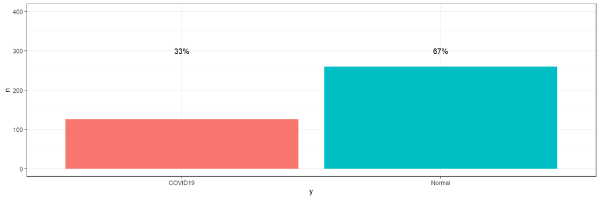

```r
dataset %>% janitor::tabyl(y) %>%
  mutate(percent=scales::percent(percent)) %>%
ggplot(aes(x=y, fill=y,y=n))+
  geom_bar(stat = 'identity')+
  ylim(c(0,400))+
  theme_bw()+
  geom_text(aes(x=y, y=300, label=percent))+
  theme(legend.position = 'none')
```

## 0.3 Feature extraction

```r
# calculate correlation matrix
corrMat <- cor(X_train)
dim(corrMat)
```

```
## [1] 784 784
```

```r
# find attributes that are highly corrected (ideally >0.75)
set.seed(1234)
highCorr <-findCorrelation(corrMat, cutoff = .75)# returned that indicates which columns should be removed.
length(highCorr)
```

```
## [1] 542
```

```r
head(highCorr)
```

```
## [1]  3  4  5  6 10 11
```

```r
filteredX_train <- X_train[, -highCorr]
dim(filteredX_train)
```

```
## [1] 290 242
```

```r
## Compute the area under the ROC curve, sensitivity, specificity,
## accuracy and Kappa

fiveStats <- function(...) c(twoClassSummary(...),
                              defaultSummary(...))
 ## Create resampling data sets to use for all models
set.seed(104)
index <- createMultiFolds(Y_train, times = 5)

## The built-in random forest functions are in rfFuncs.
str(rfFuncs)
newRF <- rfFuncs
newRF$summary <- fiveStats
subsets <- c(1:5, 10, 15, 20, 25)
# define the control using a random forest selection function
ctrl <- rfeControl(method = "cv", number=10,
                   functions = newRF,
                   verbose = T)
# run the RFE algorithm
set.seed(721)
rfRFE <- rfe(x = filteredX_train,
             y = Y_train,
             metric = "ROC",
             rfeControl = ctrl,
             sizes= subsets,
              tuneLength = 12,
             ## now pass options to randomForest()
             ntree = 1000)


# list the chosen features

ReducedSet <- rfRFE$variables %>% arrange(desc(COVID19)) %>% filter(!duplicated(var)) %>% head(100)
```

```r
# summarize the results
print(rfRFE)
```

```
##
## Recursive feature selection
##
## Outer resampling method: Cross-Validated (10 fold)
##
## Resampling performance over subset size:
##
##  Variables    ROC   Sens   Spec Accuracy  Kappa   ROCSD SensSD  SpecSD
##          1 0.8021 0.5900 0.9482   0.8311 0.5748 0.10588 0.2004 0.04964
##          2 0.8717 0.6744 0.9282   0.8455 0.6272 0.10035 0.1783 0.05522
##          3 0.9204 0.7589 0.9184   0.8665 0.6877 0.06696 0.1560 0.05446
##          4 0.9392 0.8100 0.9182   0.8833 0.7321 0.04767 0.1172 0.05484
##          5 0.9569 0.7689 0.9542   0.8941 0.7458 0.04270 0.1785 0.05566
##         10 0.9632 0.8400 0.9587   0.9210 0.8092 0.05303 0.1989 0.04756
##         15 0.9776 0.8600 0.9642   0.9310 0.8360 0.02877 0.1385 0.03416
##         20 0.9797 0.8811 0.9742   0.9448 0.8695 0.02953 0.1086 0.02720
##         25 0.9823 0.9022 0.9845   0.9584 0.9007 0.02745 0.1103 0.02501
##        242 0.9883 0.8700 0.9897   0.9517 0.8790 0.02491 0.1790 0.02165
##  AccuracySD KappaSD Selected
##     0.06278 0.18327
##     0.07004 0.18400
##     0.06833 0.16589
##     0.04756 0.11027
##     0.07290 0.18212
##     0.06869 0.17567
##     0.04304 0.11005
##     0.03334 0.08344
##     0.03935 0.09765
##     0.06339 0.16423        *
##
## The top 5 variables (out of 242):
##    X757, X760, X189, X555, X612
```

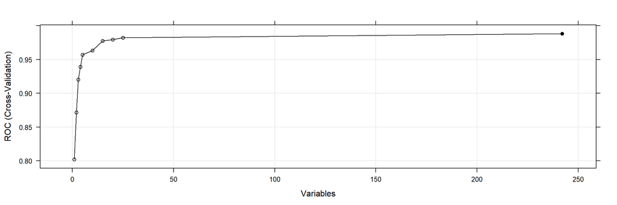

```r
# plot the results
trellis.par.set(caretTheme())
plot(rfRFE, type = c("g", "o"))
```

```r
# The top 5 variables (out of 225):
 #  X757, X760, X176, X131, X189

filteredX_train <- filteredX_train %>%
  dplyr::select(ReducedSet$var)
dim(filteredX_train)
```

```
## [1] 290 100
```

```r
TestData <- X_test %>% dplyr::select( names(filteredX_train))
```

#### 0.3.0.1 Naive Bayes

We will now use Naive Bayes to train a couple of prediction models. Both models will be generated using 10-fold cross validation, with the default parameters.

The difference between the models will be that the first one does not use the Laplace correction and lets the training procedure figure out whether to user or not a kernel density estimate, while the second one searches Laplace parameter from 0 to 5 ( best fL=0) and explicitly forbids the use of a kernel density estimate (useKernel=FALSE).

```r
#Naive algorithm
set.seed(1234)
NB_Model1 <- train(filteredX_train, Y_train,
                    method = "nb",
                    metric = "ROC",
                    #preProcess=c("scale","center"),
                    trControl= train_control)
```

```r
# results
confusionMatrix(NB_Model1)
```

```
## Cross-Validated (10 fold) Confusion Matrix
##
## (entries are percentual average cell counts across resamples)
##
##           Reference
## Prediction COVID19 Normal
##    COVID19    30.7    1.4
##    Normal      2.1   65.9
##
##  Accuracy (average) : 0.9655
```

```r
set.seed(1234)
# set up tuning grid
search_grid <- expand.grid(
  usekernel =  FALSE,
  fL = 0:5,
  adjust = seq(0, 5, by = 1))
NB_Model2 <- train(filteredX_train, Y_train,
                    method = "nb",
                    metric = "ROC",
                   tuneGrid=search_grid,
                    #preProcess=c("scale","center"),
                    trControl= train_control)
```

[figure not shown]

```r
# plot search grid results
plot(NB_Model2)
```

```r
# results for best model
confusionMatrix(NB_Model2)
```

```
## Cross-Validated (10 fold) Confusion Matrix
##
## (entries are percentual average cell counts across resamples)
##
##           Reference
## Prediction COVID19 Normal
##    COVID19    30.7    1.4
##    Normal      2.1   65.9
##
##  Accuracy (average) : 0.9655
```

We can assess the accuracy on our final holdout test set.

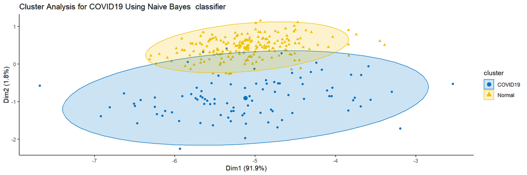

```r
# Visualize Naive Bayes clustering
predY <- predict(NB_Model2$finalModel, filteredX_train, na.action = na.pass)

fviz_cluster(list(data=filteredX_train, cluster=predY$class),
             ellipse.type = 'norm',geom = 'point',
             stand = F, palette='jco',
             main='Cluster Analysis for COVID19 Using Naive Bayes  classifier',
             ggtheme = theme_classic())
```

```r
#Predictions
Ypred_NB1 <- predict(NB_Model1, TestData)
Ypred_NB2 <- predict(NB_Model2$finalModel, TestData)
tab_NB1 <- confusionMatrix( data= Ypred_NB1,  reference= Y_test)
tab_NB2 <- confusionMatrix( data= Ypred_NB2$class,  reference=Y_test)
NB1 <- ConfMat(tab_NB1)
NB2 <- ConfMat(tab_NB2)
```

```r
model_comp <- as.data.frame(rbind(NB1,NB2))
rownames(model_comp) <- c("naive Bayes Basic", "naive Bayes _ Laplace")
pander::pander(model_comp, style="rmarkdown", split.tables=Inf, keep.trailing.zeros=TRUE,
       caption="Model results when comparing test set")
```

Model results when comparing test set

|  | TN | TP | FN | FP | acc | sens | spec |
| --- | --- | --- | --- | --- | --- | --- | --- |
| **naive Bayes Basic** | 29 | 62 | 3 | 2 | 0.95 | 0.94 | 0.95 |
| **naive Bayes _ Laplace** | 29 | 62 | 3 | 2 | 0.95 | 0.94 | 0.95 |